# Billboard Song Lyrics Analysis - Text Analytics

Alisha Gurnani

4/3/2020

For this text analysis lab I wanted to look at and compare song lyrics from 1965 and 2015 and see if there were any similarities in the word choice for the song lyrics. I used data that compiled the song lyrics of Billboard’s top 100 pop songs for those years. Because the songs are a part of completely different eras the words used in these song lyrics I believe will reflect those times and the culture for those years.

```r
lyrics <- data_frame(file = paste0(c("lyrics_1965.txt", "lyrics_2015.txt"))) %>%
  mutate(text = map(file, read_lines)) %>%
  unnest() %>%
  group_by(file = str_sub(basename(file), 1, -5)) %>%
  mutate(line_number = row_number()) %>%
  ungroup() %>%
  unnest_tokens(word, text)  %>%
  anti_join(stop_words) %>%
  mutate(word = wordStem(word))

head(lyrics)
```

| file | line_number | word |
| --- | --- | --- |
| lyrics_1965 | 1 | sam |
| lyrics_1965 | 1 | sham |
| lyrics_1965 | 1 | miscellan |
| lyrics_1965 | 1 | wooli |
| lyrics_1965 | 1 | bulli |
| lyrics_1965 | 1 | wooli |

Here I count each word per all the song lyrics for each year.

```r
lw = lyrics[ ,c("file","word")]
d =  count_(lw, c("file", "word"))
```

Below I made a document term matrix.

```r
lwdtm = d %>%
  cast_dtm(file, word, n)
```

Below I converted the document term matrix into a dataframe so I could have a better look at the different terms used in all of the song lyrics from 2015 and 1965 and how many times each term occurs in each year.

```r
mlwdtm=as.matrix(lwdtm)
df.mlwdtm=as.data.frame(mlwdtm)


t.t = t(mlwdtm)
head(t.t, 50)
```

```
##                             Docs
## Terms                        lyrics_1965 lyrics_2015
##   10                                   1           1
##   11                                   1           0
##   1949                                 1           0
##   1955                                 1           0
##   1965                                 1           0
##   20th                                 1           0
##   23                                   1           1
##   3                                    1           4
##   45                                   1           0
##   7                                    1           1
##   9                                    7           1
##   aah                                  1           2
##   accord                               2           0
##   ach                                  1           3
##   adam                                 1           2
##   add                                  1           1
##   adieu                                2           4
##   adown                                1           0
##   advertis                             1           0
##   advic                                8           2
##   affect                               1           1
##   afraid                               1           4
##   ago                                  4           5
##   ah                                  30          22
##   ahahahahah                           2           0
##   ahhhhhhhhhhhhhhhhhhhhhhhh            1           0
##   ahhhhhhhhhhhhhhhhhhhhhhhhh           1           0
##   ahyeahalrightoh                      1           0
##   aint                                47         123
##   alabama                              1           0
##   algebra                              2           0
##   alibi                                1           0
##   allbut                               1           0
##   alligatorcom                         1           0
##   alot                                 1           0
##   alright                              7          12
##   amazon                               1           0
##   amus                                 1           0
##   analyz                               1           0
##   angel                                1           0
##   angri                                1           0
##   anoth                                2           0
##   anybodi                              3           0
##   anymor                               4           5
##   anytim                               1           0
##   anywaygotta                          1           0
##   appear                               1           0
##   apron                                1           0
##   ari                                  1           1
##   arm                                 18          19
```

Below we can look at the most distinctive words for all of the songs for the year 1965 and 2015.

```r
df.t.t = as.data.frame(t.t)

summing = function(x) x/sum(x, na.rm=T)

df.t.t.2 = apply(df.t.t, 2, summing)

df.t.t$names<-rownames(df.t.t)
df.t.t = as.data.frame(t.t)
df.t.t$names<-rownames(df.t.t)
head(df.t.t)
```

|  | lyrics_1965 | lyrics_2015 | names |
| --- | --- | --- | --- |
| 10 | 1 | 1 | 10 |
| 11 | 1 | 0 | 11 |
| 1949 | 1 | 0 | 1949 |
| 1955 | 1 | 0 | 1955 |
| 1965 | 1 | 0 | 1965 |
| 20th | 1 | 0 | 20th |

```r
df.t.t.2 = as.data.frame(df.t.t.2)
df.t.t.2$names<-rownames(df.t.t.2)
df.t.t.2 = as.data.frame(df.t.t.2)

total <- merge(df.t.t,df.t.t.2,by="names")

head(total)
```

|  | names | lyrics_1965.x | lyrics_2015.x | lyrics_1965.y | lyrics_2015.y |
| --- | --- | --- | --- | --- | --- |
| 1 | 1 | 0 | 9 | 0.000000000 | 6.314460e-04 |
| 2 | 10 | 1 | 1 | 0.000158554 | 7.016067e-05 |
| 3 | 100 | 0 | 2 | 0.000000000 | 1.403213e-04 |
| 4 | 1000 | 0 | 1 | 0.000000000 | 7.016067e-05 |
| 5 | 100000 | 0 | 3 | 0.000000000 | 2.104820e-04 |
| 6 | 11 | 1 | 0 | 0.000158554 | 0.000000e+00 |

```r
total$lyrics65.over.lyrics15 = (total$lyrics_1965.y) - (total$lyrics_2015.y)
sort.OT <- total[order(total$lyrics65.over.lyrics15) , ]
sort.OT[1:30, ]
```

|  | names | lyrics_1965.x | lyrics_2015.x | lyrics_1965.y | lyrics_2015.y | lyrics65.over.lyrics15 |
| --- | --- | --- | --- | --- | --- | --- |
| 1560 | im | 114 | 541 | 0.0180751546 | 0.037956921 | -0.019881767 |
| 3350 | wanna | 10 | 153 | 0.0015855399 | 0.010734582 | -0.009149042 |
| 1262 | fuck | 0 | 117 | 0.0000000000 | 0.008208798 | -0.008208798 |
| 350 | bitch | 0 | 108 | 0.0000000000 | 0.007577352 | -0.007577352 |
| 2137 | nigga | 0 | 98 | 0.0000000000 | 0.006875745 | -0.006875745 |
| 2045 | monei | 4 | 105 | 0.0006342160 | 0.007366870 | -0.006732654 |
| 3365 | watch | 4 | 93 | 0.0006342160 | 0.006524942 | -0.005890726 |
| 2227 | ooh | 6 | 72 | 0.0009513239 | 0.005051568 | -0.004100244 |
| 1327 | gonna | 27 | 117 | 0.0042809577 | 0.008208798 | -0.003927840 |
| 3472 | worth | 1 | 51 | 0.0001585540 | 0.003578194 | -0.003419640 |

[output cut: 20 more lines]

Below I plotted a graph to view the outliers for the song lyrics of both years.

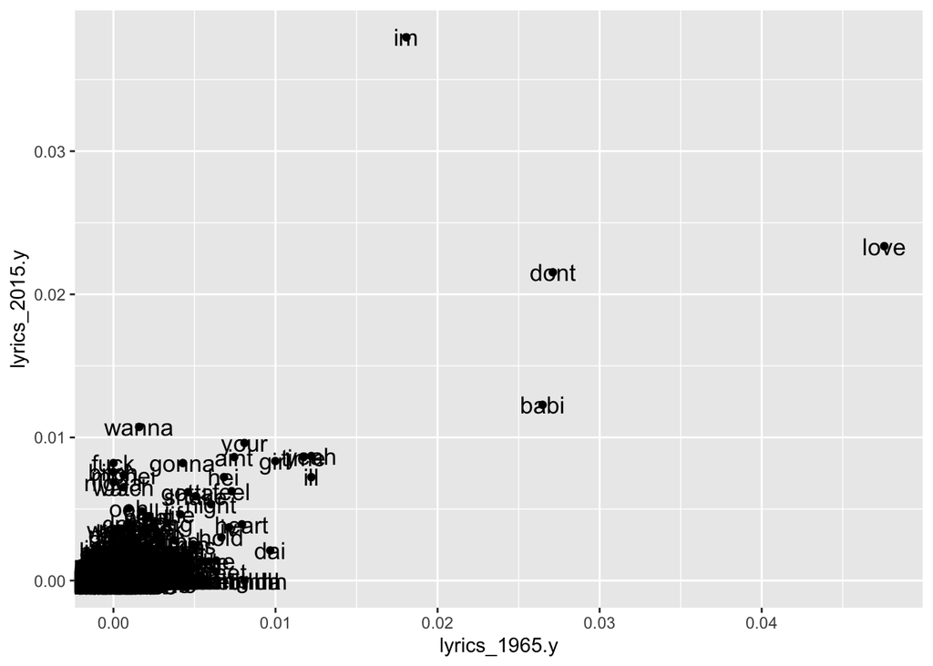

```r
q = qplot(lyrics_1965.y, lyrics_2015.y, data = total)
q + geom_text(aes(label=names), size = 4.5)
```

Below I calculated the total number of words in all of the song lyrics combined for each year. The first number refers to the total number of words for 1965 and the second number refers to the total number of words for 2015.

```r
sum(total$lyrics_1965.x, na.rm=T)
```

```
## [1] 6307
```

```r
sum(total$lyrics_2015.x, na.rm=T)
```

```
## [1] 14253
```

I ran a Pearson correlation to look at how correlated the lyrics from 1965 and 2015 are. Below is the Pearson correlation coefficient for the two years, which we can see is 0.74.

```r
cor(t.t, method="pearson")
```

```
##             lyrics_1965 lyrics_2015
## lyrics_1965   1.0000000   0.7422291
## lyrics_2015   0.7422291   1.0000000
```

I also ran the cosine correlation below which we can see shows that the song lyrics of 1965 and 2015 have a cosine similarity of 0.75.

```r
#install.packages("lsa")
library(lsa)
cosine(t.t)
```

```
##             lyrics_1965 lyrics_2015
## lyrics_1965   1.0000000   0.7549545
## lyrics_2015   0.7549545   1.0000000
```

```r
ctable <- table(t.t)
chisq.test(ctable)
```

```
##
##  Chi-squared test for given probabilities
##
## data:  ctable
## X-squared = 163247, df = 85, p-value < 2.2e-16
```

Below I also looked at the term frequency inverse year frequency. So I isolated the words that are most associated with one year or the other.

```r
d= df.mlwdtm
idf <- log(nrow(d)/colSums(d))
tfidf <- d
```

```r
for(word in names(idf)){
  tfidf[,word] <- df.mlwdtm[,word] * idf[word]
}

head(round(tfidf, 2))
```

|  | 10 | 11 | 1949 | 1955 | 1965 | 20th | 23 | 3 | 45 | 7 | 9 | aah | accord | ach | adam | add | adieu | adown | advertis | advic | affect | afraid | ago | ah | ahahahahah | ahhhhhhhhhhhhhhhhhhhhhhhh | ahhhhhhhhhhhhhhhhhhhhhhhhh | ahyeahalrightoh | aint | … |
| --- | --- | --- | --- | --- | --- | --- | --- | --- | --- | --- | --- | --- | --- | --- | --- | --- | --- | --- | --- | --- | --- | --- | --- | --- | --- | --- | --- | --- | --- | --- |
| lyrics_1965 | 0 | 0.69 | 0.69 | 0.69 | 0.69 | 0.69 | 0 | -0.92 | 0.69 | 0 | -9.70 | -0.41 | 0 | -0.69 | -0.41 | 0 | -2.20 | 0.69 | 0.69 | -12.88 | 0 | -0.92 | -6.02 | -97.74 | 0 | 0.69 | 0.69 | 0.69 | -208.80 | … |
| lyrics_2015 | 0 | 0.00 | 0.00 | 0.00 | 0.00 | 0.00 | 0 | -3.67 | 0.00 | 0 | -1.39 | -0.81 | 0 | -2.08 | -0.81 | 0 | -4.39 | 0.00 | 0.00 | -3.22 | 0 | -3.67 | -7.52 | -71.68 | 0 | 0.00 | 0.00 | 0.00 | -546.45 | … |

```r
m.tfidf=as.matrix(tfidf)
df.m.tfidf=as.data.frame(m.tfidf)
```

```r
## make the dtm into a tdm instead ##

t.df.m.tfidf = t(df.m.tfidf)

t.df.m.tfidf=as.data.frame(t.df.m.tfidf)

head(t.df.m.tfidf, 25)
```

|  | lyrics_1965 | lyrics_2015 |
| --- | --- | --- |
| 10 | 0.0000000 | 0.0000000 |
| 11 | 0.6931472 | 0.0000000 |
| 1949 | 0.6931472 | 0.0000000 |
| 1955 | 0.6931472 | 0.0000000 |
| 1965 | 0.6931472 | 0.0000000 |
| 20th | 0.6931472 | 0.0000000 |
| 23 | 0.0000000 | 0.0000000 |
| 3 | -0.9162907 | -3.6651629 |
| 45 | 0.6931472 | 0.0000000 |
| 7 | 0.0000000 | 0.0000000 |

[output cut: 15 more lines]

```r
cor(t.df.m.tfidf, method="pearson")
```

```
##             lyrics_1965 lyrics_2015
## lyrics_1965   1.0000000   0.8052943
## lyrics_2015   0.8052943   1.0000000
```

Looking at the table above we can see the inverse weightings for the song lyrics of the two years.

Based on these inverse weightings I also found the Pearson correlation is .80 which means that there is a slightly strong and positive relationship between the song lyrics in the two years.

I decided to create word clouds to look at the most common words in song lyrics of 1965 and 2015.

Below is the word cloud for all of the lyrics from Billboard’s top 100 songs in 1965

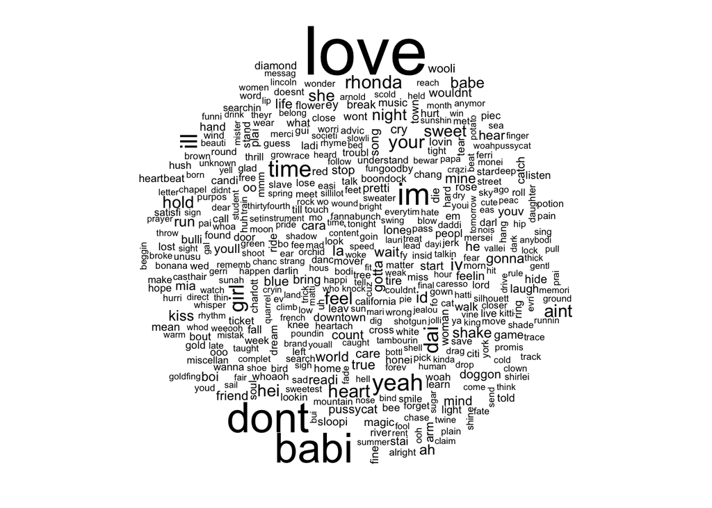

```r
##install.packages("wordcloud")
library(wordcloud)
wordcloud(df.t.t$names, df.t.t$lyrics_1965, min.freq=3, random.color=T, ordered.colors=T)
```

Below is the word cloud for all of the lyrics from Billboard’s top 100 songs in 2015

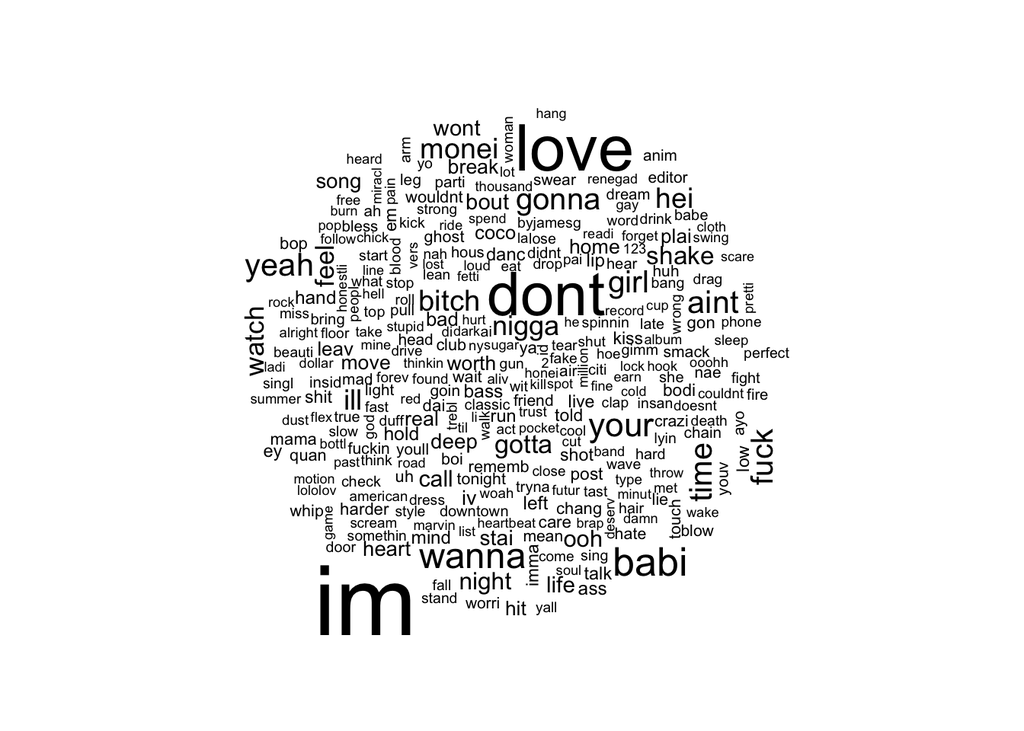

```r
wordcloud(df.t.t$names, df.t.t$lyrics_2015, min.freq=10, random.color=T, ordered.colors=T)
```

In the above 2015 word cloud we can see several explicit words that are larger and that do not appear in the 1965 word cloud, suggesting maybe that our culture is more desensitized towards these explicit words.

Lastly, I decided to conduct a sentiment analysis looking at all of the positive and negative words in the song lyrics for 1965 and 2015. Below I first look at how many words in the song lyrics of 1965 had a positive connotation and how many had a negative connotation.

```r
lyrics_sentiment <- inner_join(lyrics, get_sentiments("bing")) %>%
  filter(file == "lyrics_1965") %>%
  group_by(sentiment) %>%
  summarise(word_count = n()) %>%
  ungroup() %>%
  mutate(sentiment = reorder(sentiment, word_count))
```

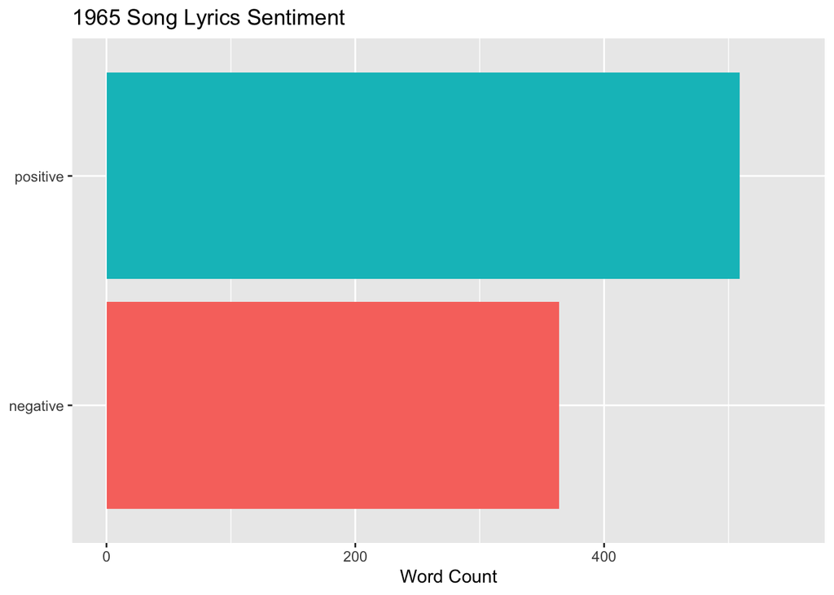

```r
sentimentplot1 <- lyrics_sentiment %>%
  ggplot(aes(sentiment, word_count, fill = sentiment)) +
  geom_col() +
  guides(fill = FALSE) +
  labs(x = NULL, y = "Word Count") +
  scale_y_continuous(limits = c(0, 550)) +
  ggtitle("1965 Song Lyrics Sentiment") +
  coord_flip()


sentimentplot1
```

In the above plot we can see that 1965 song lyrics had more positive words than negative.

Then I looked at how many words in the song lyrics of 2015 had a positive connotation and how many had a negative connotation.

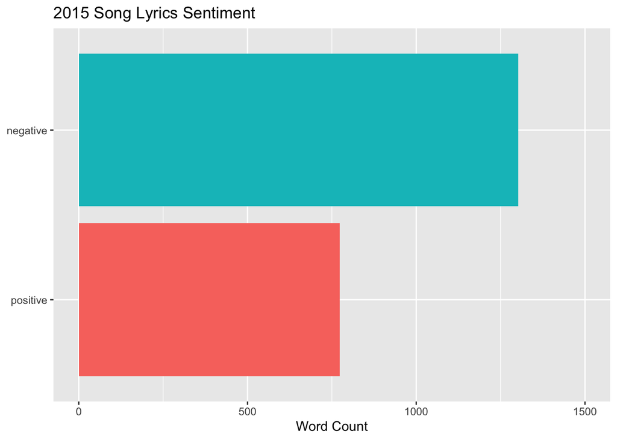

```r
lyrics_sentiment2 <- inner_join(lyrics, get_sentiments("bing")) %>%
  filter(file == "lyrics_2015") %>%
  group_by(sentiment) %>%
  summarise(word_count = n()) %>%
  ungroup() %>%
  mutate(sentiment = reorder(sentiment, word_count))


sentimentplot2 <- lyrics_sentiment2 %>%
  ggplot(aes(sentiment, word_count, fill = sentiment)) +
  geom_col() +
  guides(fill = FALSE) +
  labs(x = NULL, y = "Word Count") +
  scale_y_continuous(limits = c(0, 1500)) +
  ggtitle("2015 Song Lyrics Sentiment") +
  coord_flip()


sentimentplot2
```

In the above plot we can see that the song lyrics from 2015 had more words with a negative connotation than positive.